# Art Zaragoza_Neural_Networks_Customer_Churn_Project4_Full_code

#### Exited Vs Is active member

```
IsActiveMember     0     1    All
Exited
All             4849  5151  10000
0               3547  4416   7963
1               1302   735   2037
------------------------------------------------------------------------------------------------------------------------
```

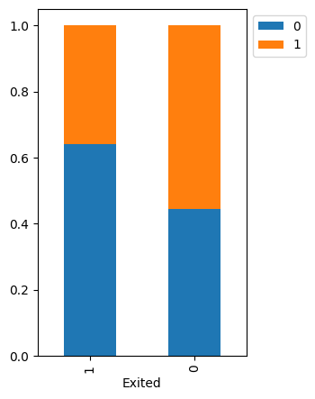

```python
stacked_barplot(ds, "Exited","IsActiveMember" )
```

#### Exited Vs Credit Score

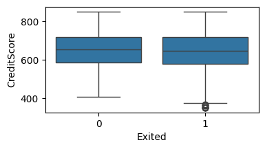

```python
plt.figure(figsize=(4,2))
sns.boxplot(y='CreditScore',x='Exited',data=ds)
plt.show()
```

Observations:

- Distribution of Credit Score of Customers and the average are about the same for those that stay and those that leave.
- There's a number of Outliers for those that leave.

#### Exited Vs Age

This Age feature had one of the two strongest correlation with Exiting Customers:

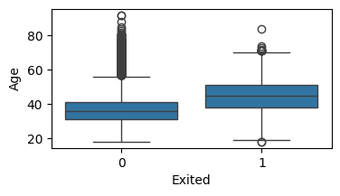

```python
plt.figure(figsize=(4,2))
sns.boxplot(y='Age',x='Exited',data=ds)
plt.show()
```

Observations:

- The average Customer Age that left the bank is between 40-50.

Recommendations:

- Investigate contributing factors.

#### Exited Vs Tenure

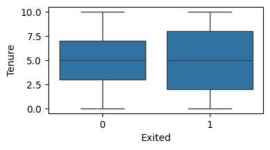

```python
plt.figure(figsize=(4,2))
sns.boxplot(y='Tenure',x='Exited',data=ds) # Boxplot for Exited and Tenure
plt.show()
```

Observations:

- The average are about the same for those that stay and those that live.
- However, the distribution is wider for those Customers that leave.

#### Exited Vs Balance

This Balance feature had one of the two strongest correlation with Exiting Customers after Age:

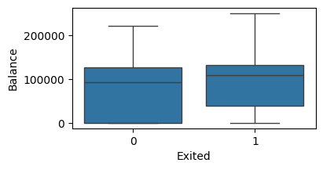

```python
plt.figure(figsize=(4,2))
sns.boxplot(y='Balance',x='Exited',data=ds)               ## Complete the code to plot the boxplot for Exited and Balance
plt.show()
```

Observations:

Recommendations:

- Further analysis is required here.

#### Exited Vs Number of Products

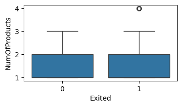

```python
plt.figure(figsize=(4,2))
sns.boxplot(y='NumOfProducts',x='Exited',data=ds)               ## Complete the code to plot the boxplot for Exited and Number of products
plt.show()
```

Observations:

- Distribution of Number of Products used by Customers are about the same for those that stay and those that leave.

#### Exited Vs Estimated Salary

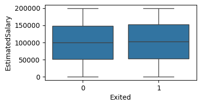

```python
plt.figure(figsize=(4,2))
sns.boxplot(y='EstimatedSalary',x='Exited',data=ds)               ## Complete the code to plot the boxplot for Exited and Estimated Salary
plt.show()
```

Observations:

- Distribution of Estimated Salary of Customers and the average are about the same for those that stay and those that live.

## Data Preprocessing --------------------------------------------------------------- Section

### Categorical Encoding with Dummy Variable Creation - Data Preprocessing

```python
# Identifying all categorical columns.
	# •	Convert them to (one-hot encoded) columns.
	# •	Dropping the first category from each categorical variable to avoid multicollinearity.
	# •	Encoded columns are of type float.
ds = pd.get_dummies(ds,columns=ds.select_dtypes(include=["object"]).columns.tolist(),drop_first=True,dtype=float)
print("Categorical Encoding done where needed (object datatypes).")
```

```
Categorical Encoding done where needed (object datatypes).
```

### Train | Validation | Test (Splits) - Data Preprocessing

Separate features from results columns into two tables for handling prediction training and testing datasets:

```python
X = ds.drop(['Exited'],axis=1) # Remove Exited column from Credit Score through Estimated Salary on X table.
y = ds['Exited'] # Assign our Target feature Exited to y table.
```

```python
print("Features Table or X_large = ", X.shape, "\nResults Table or y_large = ", y.shape) # Confirm features table versus results table.
```

```
Features Table or X_large =  (10000, 11)
Results Table or y_large =  (10000,)
```

1st Split - Temporary X_large dataset (for Train/Validation datasets)the and he Test dataset Split:

```python
# Splitting the entire dataset into the Training and Testing data sets.
# The Test data set is not used until the end of the process to evaluate the final performance of the model on completely unseen data.
X_large, X_test, y_large, y_test = train_test_split(X, y, test_size = 0.20, random_state = 42,stratify=y,shuffle = True)
```

This will leave 20% of the available data for the Test dataset and 80% of the data for the train and validation data sets combined.

- The full allocation is 80% of the data (64% of the original data) for training, and 20% of the 80% data (16% of the original data) for validation.

```python
print("\nTrain/Validation features data (X_large) = ",X_large.shape, "with corresponding Results (y_large) = ",y_large.shape,"\nTest features data (x_test) = ", X_test.shape, "with corresponding Test results data",y_test.shape) # Check splits allocations.
```

```
Train/Validation features data (X_large) =  (8000, 11) with corresponding Results (y_large) =  (8000,)
Test features data (x_test) =  (2000, 11) with corresponding Test results data (2000,)
```

2nd Split - Temporary X_large dataset split into Train and Validation datasets:

```python
# Splitting the temporaty X_large dataset into the Training and Validation data sets.
X_train, X_val, y_train, y_val = train_test_split(X_large, y_large, test_size = 0.20, random_state = 42,stratify=y_large, shuffle = True) # The validation set is used during the training process to fine-tune model parameters and to avoid overfitting. It helps to evaluate how well the model is generalizing *without* touching the test set.
```

```python
# After split checks.
print("\nTrain/Validation features data (X_large) = ",X_large.shape, "with corresponding Results (y_large) = ",y_large.shape)
print("Above was split as follows:")
print("\nTraining features data (X_train) = ", X_train.shape, "with corresponding Results (y_large) = ",y_train.shape,"\nValidation features data (X_val) = ", X_val.shape, "with corresponding Validation Results (y_val) = ",y_val.shape)
print("\n - - - - - - - - Test dataset will be used to verify training model on unseen data (X_test) = ", X_test.shape)
```

```
Train/Validation features data (X_large) =  (8000, 11) with corresponding Results (y_large) =  (8000,)
Above was split as follows:

Training features data (X_train) =  (6400, 11) with corresponding Results (y_large) =  (6400,)
Validation features data (X_val) =  (1600, 11) with corresponding Validation Results (y_val) =  (1600,)

 - - - - - - - - Test dataset will be used to verify training model on unseen data (X_test) =  (2000, 11)
```

```python
# EXTRA CREDIT (Visualize Splits)
# Check the shapes of the training, validation, and test sets adjacent to each other with colored text
print("\nX_Large =", X_large.shape,"is further split into training and validation. Presented here for easier visualizations:")
print(f"\033[33mTrain set shape: {X_train.shape}\033[0m", end=' | ')  # Orange color for train
print(f"\033[32mValidation set shape: {X_val.shape}\033[0m", end=' | ')  # Green color for validation
print(f"\033[35mTest set shape: {X_test.shape}\033[0m")  # Violet color for test

print("\n")
print(f"1. Original set shape: {X.shape}")
print("|" * 100)  # Print a line separator.
# X is your feature data, and y is your target data


# First split: Splits data into 80% training+validation (X_large, y_large) and 20% test (X_test, y_test)
print("\n\n2. First split: Splits the data into 80% \033[1;4mtemporay (temp)\033[0m (X_large, y_large) and \033[35m20% test (X_test, y_test).\033[0m")
print("|" * 80, "\033[35m|\033[0m" * 20)  # Line separator to show split visually
print(f"Temporary (temp) set shape: {X_large.shape}")
print(f"\033[35mTest set shape: {X_test.shape}\033[0m\n")

# Second split: Subsplit X_large and y_large into 80% training and 20% validation
print("\n3. Second split: Subsplits the (temp) dataset into the \033[1;4mtraining (64% of total) + validation set (16% of total),\033[0m \nor (X_Large, y_large) = (X_train, y_train) + (X_val, y_val).")
print("\033[1;33mt\033[0m" * 64, "\033[1;32mv\033[0m" * 16, "\033[1;35mT\033[0m" * 20)  # Line separator with t for training and v for validation
print(f"\033[1;33mTraining set shape (t): {X_train.shape}\033[0m") # Training set
print(f"\033[1;32mValidation set shape (v): {X_val.shape}\033[0m") # Validation set
print(f"\033[35mTest set shape (T): {X_test.shape}\033[0m") # Test set
```

```
X_Large = (8000, 11) is further split into training and validation. Presented here for easier visualizations:
Train set shape: (6400, 11) | Validation set shape: (1600, 11) | Test set shape: (2000, 11)


1. Original set shape: (10000, 11)
||||||||||||||||||||||||||||||||||||||||||||||||||||||||||||||||||||||||||||||||||||||||||||||||||||


2. First split: Splits the data into 80% temporay (temp) (X_large, y_large) and 20% test (X_test, y_test).
|||||||||||||||||||||||||||||||||||||||||||||||||||||||||||||||||||||||||||||||| ||||||||||||||||||||
Temporary (temp) set shape: (8000, 11)
Test set shape: (2000, 11)


3. Second split: Subsplits the (temp) dataset into the training (64% of total) + validation set (16% of total),
or (X_Large, y_large) = (X_train, y_train) + (X_val, y_val).
tttttttttttttttttttttttttttttttttttttttttttttttttttttttttttttttt vvvvvvvvvvvvvvvv TTTTTTTTTTTTTTTTTTTT
Training set shape (t): (6400, 11)
Validation set shape (v): (1600, 11)
Test set shape (T): (2000, 11)
```

### Data Normalization - Data Preprocessing

Since all the numerical values are on a different scale, we will scale them. To normalize them to the same scale:

```python
# Define cols_list as all columns except 'Exited'
#cols_list = [col for col in X_train.columns if col != 'Exited']  # Replace X_train with your feature dataframe name if different
cols_list = [col for col in cols_list if col != 'Exited'] # Target Variable separated from the the feature variables.

# creating an instance of the standard scaler
sc = StandardScaler()

# Apply scaling to the specified columns
X_train[cols_list] = sc.fit_transform(X_train[cols_list])  # Scaling for training set
X_val[cols_list] = sc.transform(X_val[cols_list])          # Scaling for validation set
X_test[cols_list] = sc.transform(X_test[cols_list])        # Scaling for test set
```

Why using **StandardScaler()** is important, specially with Neural Networks:

1. Feature Scaling: Many machine learning algorithms assume that the features in the dataset are centered around 0 and have similar scales. If the features vary widely in terms of scale (e.g., one feature is measured in dollars while another is measured in grams), it can cause the model to perform poorly because larger scaled features **may dominate the learning process**. StandardScaler standardizes features by subtracting the mean and dividing by the standard deviation.
2. Avoid Bias Toward Larger-Scaled Features: Without scaling, features with larger numerical values **will have a greater effect on the model’s behavior**, even if they aren’t inherently more important. For example, a feature with values in the thousands will dominate over a feature with values in the range of 1 to 10.
3. Improved Model Convergence: Many optimization algorithms, **like gradient descent, work faster and converge more efficiently** when the data is scaled. If the features are on different scales, the optimization process can take longer and be less effective.
4. Neural Networks: In neural networks, scaling input features is particularly important because `it ensures that gradients flow more smoothly` through the network, preventing issues like vanishing or exploding gradients.

## Model Building ---------------------------------------------------------------------- Section

### Model Evaluation Rationale - Model Building

Logic for choosing the metric that would be the best metric for this business scenario.

**Let's create a function for plotting the confusion matrix**

```python
def make_confusion_matrix(actual_targets, predicted_targets):
    """
    To plot the confusion_matrix with percentages

    actual_targets: actual target (dependent) variable values
    predicted_targets: predicted target (dependent) variable values
    """
    cm = confusion_matrix(actual_targets, predicted_targets)
    labels = np.asarray(
        [
            ["{0:0.0f}".format(item) + "\n{0:.2%}".format(item / cm.flatten().sum())]
            for item in cm.flatten()
        ]
    ).reshape(cm.shape[0], cm.shape[1])

    plt.figure(figsize=(3, 2))
    sns.heatmap(cm, annot=labels, fmt="")
    plt.ylabel("True label")
    plt.xlabel("Predicted label")
```

Let's create two blank dataframes that will store the recall values for all the models we build.

```python
train_metric_df = pd.DataFrame(columns=["recall"])
valid_metric_df = pd.DataFrame(columns=["recall"])
```

### Neural Network with SGD Optimizer - Model Building

Stochastic Gradient Descent keras optimizer:

- PROs
  - Faster for large datasets.
  - Requires computing gradients and weight calculations for the entire data.
  - Because its stochastic nature, SGD can escape local minima and potentially find better solutions.
- CONs
  - Nosy Updates making it less stable leading to oscillations.
  - Requires Tuning of learning rates and other hyperparameters.
  - Slower Convergance compared to Adam (Adaptive)

```python
backend.clear_session() # Clear any previous models or computational graphs in memory
print("Previous models or computational graphs in memory have been cleared.")

# By setting a “seed,” we control the random number generators so that they produce the same random numbers every time.
print("\nNow, we set the seed for NumPy, Python, and TensorFlow random generators ...\n")

np.random.seed(2) # Fixes the seed for NumPy’s random number generator.
random.seed(2) # Fixes the seed for Python’s built-in random number generator.
tf.random.set_seed(2) # Fixes the seed for TensorFlow’s random number generator.
print("Why? Because some parts of machine learning (like initializing weights or shuffling data) involve randomness.")
print("We need to produce the same random numbers every time producing consisten results for testing machine learning models.")
```

```
Previous models or computational graphs in memory have been cleared.

Now, we set the seed for NumPy, Python, and TensorFlow random generators ...

Why? Because some parts of machine learning (like initializing weights or shuffling data) involve randomness.
We need to produce the same random numbers every time producing consisten results for testing machine learning models.
```

```python
#Initializing the neural network
model_0 = Sequential()
# Adding the input layer with 64 neurons and relu as activation function
model_0.add(Dense(64, activation='relu', input_dim = X_train.shape[1]))
# Complete the code to add a hidden layer (specify the # of neurons and the activation function)
model_0.add(Dense(32, activation='relu'))
# Complete the code to add the output layer with the number of neurons required.
model_0.add(Dense(1, activation = 'sigmoid'))

print("Neural Network initialized...\n")
print("Hidden Layer: 32 neurons with the ReLU activation function.")
print("Output Layer: 1 neuron with the sigmoid activation function.")
print("Note: For binary classification tasks, using a single neuron with the sigmoid function is common because it outputs probabilities between 0 and 1.\n")
```

```
Neural Network initialized...

Hidden Layer: 32 neurons with the ReLU activation function.
Output Layer: 1 neuron with the sigmoid activation function.
Note: For binary classification tasks, using a single neuron with the sigmoid function is common because it outputs probabilities between 0 and 1.
```

```python
optimizer = tf.keras.optimizers.SGD(learning_rate=0.001) # SGD(learning_rate=0.001)SGD:
# This is the stochastic gradient descent optimizer, which controls the step size for each iteration during the optimization process.
print("\nStochastic Gradient Descent optimizer (SDG) set up. \nIt controls step size for each iteration during optimization process.\n")
# uncomment one of the following lines to define the metric to be used
# metric = 'accuracy'
metric = keras.metrics.Recall()
# metric = keras.metrics.Precision()
# metric = keras.metrics.F1Score()
print("Recall metric setup.\n")
```

```
Stochastic Gradient Descent optimizer (SDG) set up.
It controls step size for each iteration during optimization process.

Recall metric setup.
```

```python
# Binary cross entropy as loss function and Recall metric setup.
model_0.compile(loss='binary_crossentropy', optimizer=optimizer, metrics=[keras.metrics.Recall()])
print("\nloss = 'binary_crossentropy'setup: This is the appropriate loss function for binary classification tasks, measuring the difference between the Predicted and Actual values.\n")
print("metrics = [keras.metrics.Recall()] setup: This specifies that recall will be used as a metric to evaluate the model’s performance during training and testing.\n")
```

```
loss = 'binary_crossentropy'setup: This is the appropriate loss function for binary classification tasks, measuring the difference between the Predicted and Actual values.

metrics = [keras.metrics.Recall()] setup: This specifies that recall will be used as a metric to evaluate the model’s performance during training and testing.
```

```python
model_0.summary()
```

```
Model: "sequential"
```

```
┏━━━━━━━━━━━━━━━━━━━━━━━━━━━━━━━━━━━━━━┳━━━━━━━━━━━━━━━━━━━━━━━━━━━━━┳━━━━━━━━━━━━━━━━━┓
┃ Layer (type)                         ┃ Output Shape                ┃         Param # ┃
┡━━━━━━━━━━━━━━━━━━━━━━━━━━━━━━━━━━━━━━╇━━━━━━━━━━━━━━━━━━━━━━━━━━━━━╇━━━━━━━━━━━━━━━━━┩
│ dense (Dense)                        │ (None, 64)                  │             768 │
├──────────────────────────────────────┼─────────────────────────────┼─────────────────┤
│ dense_1 (Dense)                      │ (None, 32)                  │           2,080 │
├──────────────────────────────────────┼─────────────────────────────┼─────────────────┤
│ dense_2 (Dense)                      │ (None, 1)                   │              33 │
└──────────────────────────────────────┴─────────────────────────────┴─────────────────┘
```

```
 Total params: 2,881 (11.25 KB)
```

```
 Trainable params: 2,881 (11.25 KB)
```

```
 Non-trainable params: 0 (0.00 B)
```

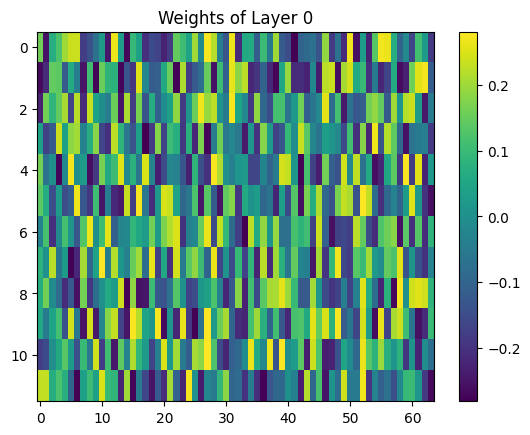

```python
# Visualize weights from the first layer
import matplotlib.pyplot as plt

weights = model_0.layers[0].get_weights()[0]
plt.imshow(weights, aspect='auto', cmap='viridis')
plt.colorbar()
plt.title('Weights of Layer {}'.format(0))
plt.show()
```

```python
# List weights and biases of the first layer
weights_layer_0 = model_0.layers[0].get_weights()
print(weights_layer_0[0])  # Weights
print(weights_layer_0[1])  # Biases
```

[output not shown]

[output cut: 132 more lines]

[output not shown]

```python
# Datasets
print("\nX_Large =", X_large.shape,"is further split into training and validation. Presented here for easier visualizations:")
print(f"\033[33mTrain set shape: {X_train.shape}\033[0m", end=' | ')  # Orange color for train
print(f"\033[32mValidation set shape: {X_val.shape}\033[0m", end=' | ')  # Green color for validation
print(f"\033[35mTest set shape: {X_test.shape}\033[0m")  # Violet color for test

# Objectives
print("_" * 100)
print(f"Main Objectives: As the model trains over more epochs ...")
print(f"We look for a LOSS decrease \u25BC and a RECALL increase \u25B2 for training and also validation sets:")
print("  • Training Loss and Validation Loss: How the loss changes over time.")
print("-" * 100)
print("\nBatch Size: We will set to 16, 32, 64, or 128.")
print("A smaller batch size can provide more updates to the NN model weights during training but may take longer,")
print("while a larger batch size may speed up training but provide fewer updates.")
print("\nEpochs: The number of epochs should depend on your specific dataset and NN model.")
print("We will start with values 10, 50, or 100, and monitor the training and validation loss/metrics")
print("to see when the NN model converges or starts to overfit.")
print("  • Recall and Validation Recall: How the ability of the model to detect true positives changes during training.\n")
```

```
X_Large = (8000, 11) is further split into training and validation. Presented here for easier visualizations:
Train set shape: (6400, 11) | Validation set shape: (1600, 11) | Test set shape: (2000, 11)
____________________________________________________________________________________________________
Main Objectives: As the model trains over more epochs ...
We look for a LOSS decrease ▼ and a RECALL increase ▲ for training and also validation sets:
  • Training Loss and Validation Loss: How the loss changes over time.
----------------------------------------------------------------------------------------------------

Batch Size: We will set to 16, 32, 64, or 128.
A smaller batch size can provide more updates to the NN model weights during training but may take longer,
while a larger batch size may speed up training but provide fewer updates.

Epochs: The number of epochs should depend on your specific dataset and NN model.
We will start with values 10, 50, or 100, and monitor the training and validation loss/metrics
to see when the NN model converges or starts to overfit.
  • Recall and Validation Recall: How the ability of the model to detect true positives changes during training.
```

```python
print(X_train.dtypes) # Check for datatypes ro ensure no Object/Category remaain unprocessed.
print(y_train.dtypes) # Check for datatypes ro ensure no Object/Category remaain unprocessed.
```

```
CreditScore          float64
Age                  float64
Tenure               float64
Balance              float64
NumOfProducts        float64
HasCrCard            float64
IsActiveMember       float64
EstimatedSalary      float64
Geography_Germany    float64
Geography_Spain      float64
Gender_Male          float64
dtype: object
int64
```

```python
# Forward Propagation Illustration - Utility Function

import time
import sys

# ANSI color codes
RED = "\033[31m"
GREEN = "\033[32m"
ORANGE = "\033[33m"
RESET = "\033[0m"

# Forward Propagation Illustration
print("\nIllustration of -Forward Propagation- by Activation Functions at each neuron based on the strenght of importance or weights between nodes.")

# Function to animate dashes with color choice, moving towards a fixed [*] position, and stop after a timeout
def animate_dashes_with_fixed_asterisk(total_time=10, speed=0.1, color="RED"):
    # Choose color based on user input
    if color == "RED":
        dash_color = RED
    elif color == "GREEN":
        dash_color = GREEN
    elif color == "ORANGE":
        dash_color = ORANGE
    else:
        dash_color = RESET  # Default to no color if an invalid option is given

    width = 10  # Initial width of dashes
    fixed_pos = 45  # Fixed position for the asterisk [*]
    start_time = time.time()  # Record the starting time

    while time.time() - start_time < total_time:
        # Calculate remaining space before the asterisk [*]
        remaining_space = fixed_pos - width - 3  # 3 accounts for the length of [*]

        if remaining_space < 0:
            remaining_space = 0  # Stop growing dashes once they reach [*]

        # Use carriage return '\r' to return to the start of the line and overwrite the previous output
        sys.stdout.write(f"\r{GREEN}[* neuron layer_i *] {dash_color}{'-' * width}{' ' * remaining_space}{ORANGE}[* neuron layer_i+1 *]{RESET}")
        sys.stdout.flush()  # Force output to appear immediately
        time.sleep(speed)   # Control the speed of the animation

        if remaining_space == 0:
            width = 10  # Reset width after dashes meet [*] to restart animation
        else:
            width += 1  # Increase the number of dashes for movement effect

    # After the timeout ends, clear the line and stop
    sys.stdout.write("\r" + " " * (fixed_pos + 3) + "\r")
    sys.stdout.flush()

# Run the animation (set timeout in seconds and specify color: "RED", "GREEN", or "ORANGE")
animate_dashes_with_fixed_asterisk(total_time=10, speed=0.08, color="GREEN")

# Leave the illustration completed without animation
print(f"\r{GREEN}[* neuron layer_i *]{GREEN} ----------------------------------------- {ORANGE}[* neuron layer_i+1 *]")
```

```
Illustration of -Forward Propagation- by Activation Functions at each neuron based on the strenght of importance or weights between nodes.
[* neuron layer_i *] ----------------------------------------- [* neuron layer_i+1 *]
```

Now, drum roll please ...

```python
# Fitting the Artificial Neural Network (ANN) Model: ORIGINAL
print("\nFitting the Artificial Neural Network (ANN) Model: SGD - our baseline ...\n")
history_0 = model_0.fit(
    X_train, y_train, # Train model on the training dataset
    batch_size=32,    # Specify the batch size to 32
    validation_data=(X_val, y_val), # Use validation dataset for evaluation of this training model. <------ Monitor
    epochs=50,    # Specify the number of epochs to 50. The model will be trained this total cycles.
    verbose=1
)
```

```
Fitting the Artificial Neural Network (ANN) Model: SGD - our baseline ...

200/200 ━━━━━━━━━━━━━━━━━━━━ 3s 4ms/step - loss: 0.6602 - recall_1: 0.3081 - val_loss: 0.6005 - val_recall_1: 0.0583
200/200 ━━━━━━━━━━━━━━━━━━━━ 0s 2ms/step - loss: 0.5963 - recall_1: 0.0376 - val_loss: 0.5584 - val_recall_1: 0.0061
200/200 ━━━━━━━━━━━━━━━━━━━━ 0s 2ms/step - loss: 0.5575 - recall_1: 0.0000e+00 - val_loss: 0.5325 - val_recall_1: 0.0000e+00
200/200 ━━━━━━━━━━━━━━━━━━━━ 0s 2ms/step - loss: 0.5332 - recall_1: 0.0000e+00 - val_loss: 0.5160 - val_recall_1: 0.0000e+00
200/200 ━━━━━━━━━━━━━━━━━━━━ 0s 2ms/step - loss: 0.5174 - recall_1: 0.0000e+00 - val_loss: 0.5050 - val_recall_1: 0.0000e+00
200/200 ━━━━━━━━━━━━━━━━━━━━ 0s 2ms/step - loss: 0.5065 - recall_1: 0.0000e+00 - val_loss: 0.4972 - val_recall_1: 0.0000e+00
200/200 ━━━━━━━━━━━━━━━━━━━━ 0s 2ms/step - loss: 0.4986 - recall_1: 0.0000e+00 - val_loss: 0.4914 - val_recall_1: 0.0000e+00
200/200 ━━━━━━━━━━━━━━━━━━━━ 0s 2ms/step - loss: 0.4924 - recall_1: 0.0000e+00 - val_loss: 0.4868 - val_recall_1: 0.0000e+00
200/200 ━━━━━━━━━━━━━━━━━━━━ 0s 2ms/step - loss: 0.4874 - recall_1: 0.0000e+00 - val_loss: 0.4829 - val_recall_1: 0.0000e+00
200/200 ━━━━━━━━━━━━━━━━━━━━ 0s 2ms/step - loss: 0.4831 - recall_1: 0.0000e+00 - val_loss: 0.4796 - val_recall_1: 0.0000e+00
200/200 ━━━━━━━━━━━━━━━━━━━━ 0s 2ms/step - loss: 0.4792 - recall_1: 0.0000e+00 - val_loss: 0.4766 - val_recall_1: 0.0000e+00
200/200 ━━━━━━━━━━━━━━━━━━━━ 0s 2ms/step - loss: 0.4757 - recall_1: 0.0000e+00 - val_loss: 0.4738 - val_recall_1: 0.0000e+00
200/200 ━━━━━━━━━━━━━━━━━━━━ 0s 2ms/step - loss: 0.4725 - recall_1: 7.6306e-06 - val_loss: 0.4712 - val_recall_1: 0.0000e+00
200/200 ━━━━━━━━━━━━━━━━━━━━ 0s 2ms/step - loss: 0.4695 - recall_1: 7.6306e-06 - val_loss: 0.4689 - val_recall_1: 0.0000e+00
200/200 ━━━━━━━━━━━━━━━━━━━━ 0s 2ms/step - loss: 0.4666 - recall_1: 7.6306e-06 - val_loss: 0.4666 - val_recall_1: 0.0031
200/200 ━━━━━━━━━━━━━━━━━━━━ 0s 2ms/step - loss: 0.4640 - recall_1: 1.3905e-04 - val_loss: 0.4645 - val_recall_1: 0.0031
200/200 ━━━━━━━━━━━━━━━━━━━━ 0s 2ms/step - loss: 0.4614 - recall_1: 0.0030 - val_loss: 0.4626 - val_recall_1: 0.0031
200/200 ━━━━━━━━━━━━━━━━━━━━ 0s 2ms/step - loss: 0.4591 - recall_1: 0.0044 - val_loss: 0.4607 - val_recall_1: 0.0123
200/200 ━━━━━━━━━━━━━━━━━━━━ 0s 2ms/step - loss: 0.4568 - recall_1: 0.0131 - val_loss: 0.4589 - val_recall_1: 0.0123
200/200 ━━━━━━━━━━━━━━━━━━━━ 0s 2ms/step - loss: 0.4546 - recall_1: 0.0139 - val_loss: 0.4573 - val_recall_1: 0.0123
200/200 ━━━━━━━━━━━━━━━━━━━━ 0s 2ms/step - loss: 0.4526 - recall_1: 0.0184 - val_loss: 0.4557 - val_recall_1: 0.0153
200/200 ━━━━━━━━━━━━━━━━━━━━ 0s 2ms/step - loss: 0.4506 - recall_1: 0.0240 - val_loss: 0.4542 - val_recall_1: 0.0184
200/200 ━━━━━━━━━━━━━━━━━━━━ 0s 2ms/step - loss: 0.4488 - recall_1: 0.0259 - val_loss: 0.4528 - val_recall_1: 0.0184
200/200 ━━━━━━━━━━━━━━━━━━━━ 0s 2ms/step - loss: 0.4470 - recall_1: 0.0306 - val_loss: 0.4514 - val_recall_1: 0.0215
200/200 ━━━━━━━━━━━━━━━━━━━━ 0s 2ms/step - loss: 0.4453 - recall_1: 0.0338 - val_loss: 0.4501 - val_recall_1: 0.0307
200/200 ━━━━━━━━━━━━━━━━━━━━ 0s 2ms/step - loss: 0.4436 - recall_1: 0.0397 - val_loss: 0.4489 - val_recall_1: 0.0429
200/200 ━━━━━━━━━━━━━━━━━━━━ 0s 2ms/step - loss: 0.4421 - recall_1: 0.0424 - val_loss: 0.4477 - val_recall_1: 0.0429
200/200 ━━━━━━━━━━━━━━━━━━━━ 0s 2ms/step - loss: 0.4406 - recall_1: 0.0525 - val_loss: 0.4466 - val_recall_1: 0.0491
200/200 ━━━━━━━━━━━━━━━━━━━━ 0s 2ms/step - loss: 0.4392 - recall_1: 0.0606 - val_loss: 0.4455 - val_recall_1: 0.0521
200/200 ━━━━━━━━━━━━━━━━━━━━ 0s 2ms/step - loss: 0.4378 - recall_1: 0.0677 - val_loss: 0.4445 - val_recall_1: 0.0583
200/200 ━━━━━━━━━━━━━━━━━━━━ 0s 2ms/step - loss: 0.4365 - recall_1: 0.0791 - val_loss: 0.4435 - val_recall_1: 0.0583
200/200 ━━━━━━━━━━━━━━━━━━━━ 0s 2ms/step - loss: 0.4353 - recall_1: 0.0903 - val_loss: 0.4425 - val_recall_1: 0.0706
200/200 ━━━━━━━━━━━━━━━━━━━━ 0s 2ms/step - loss: 0.4341 - recall_1: 0.0963 - val_loss: 0.4416 - val_recall_1: 0.0828
200/200 ━━━━━━━━━━━━━━━━━━━━ 0s 2ms/step - loss: 0.4329 - recall_1: 0.1129 - val_loss: 0.4408 - val_recall_1: 0.0890
200/200 ━━━━━━━━━━━━━━━━━━━━ 0s 2ms/step - loss: 0.4318 - recall_1: 0.1187 - val_loss: 0.4399 - val_recall_1: 0.1012
200/200 ━━━━━━━━━━━━━━━━━━━━ 0s 2ms/step - loss: 0.4307 - recall_1: 0.1224 - val_loss: 0.4391 - val_recall_1: 0.1043
200/200 ━━━━━━━━━━━━━━━━━━━━ 0s 2ms/step - loss: 0.4297 - recall_1: 0.1269 - val_loss: 0.4384 - val_recall_1: 0.1104
200/200 ━━━━━━━━━━━━━━━━━━━━ 0s 2ms/step - loss: 0.4287 - recall_1: 0.1314 - val_loss: 0.4376 - val_recall_1: 0.1135
200/200 ━━━━━━━━━━━━━━━━━━━━ 0s 2ms/step - loss: 0.4277 - recall_1: 0.1398 - val_loss: 0.4369 - val_recall_1: 0.1166
200/200 ━━━━━━━━━━━━━━━━━━━━ 0s 2ms/step - loss: 0.4267 - recall_1: 0.1470 - val_loss: 0.4362 - val_recall_1: 0.1258
200/200 ━━━━━━━━━━━━━━━━━━━━ 0s 2ms/step - loss: 0.4258 - recall_1: 0.1567 - val_loss: 0.4355 - val_recall_1: 0.1350
200/200 ━━━━━━━━━━━━━━━━━━━━ 0s 2ms/step - loss: 0.4249 - recall_1: 0.1616 - val_loss: 0.4349 - val_recall_1: 0.1411
200/200 ━━━━━━━━━━━━━━━━━━━━ 0s 2ms/step - loss: 0.4241 - recall_1: 0.1639 - val_loss: 0.4342 - val_recall_1: 0.1442
200/200 ━━━━━━━━━━━━━━━━━━━━ 0s 2ms/step - loss: 0.4232 - recall_1: 0.1732 - val_loss: 0.4336 - val_recall_1: 0.1564
200/200 ━━━━━━━━━━━━━━━━━━━━ 0s 2ms/step - loss: 0.4224 - recall_1: 0.1846 - val_loss: 0.4330 - val_recall_1: 0.1656
200/200 ━━━━━━━━━━━━━━━━━━━━ 0s 2ms/step - loss: 0.4216 - recall_1: 0.1858 - val_loss: 0.4324 - val_recall_1: 0.1718
200/200 ━━━━━━━━━━━━━━━━━━━━ 0s 2ms/step - loss: 0.4208 - recall_1: 0.1875 - val_loss: 0.4319 - val_recall_1: 0.1718
200/200 ━━━━━━━━━━━━━━━━━━━━ 0s 2ms/step - loss: 0.4201 - recall_1: 0.1935 - val_loss: 0.4313 - val_recall_1: 0.1718
200/200 ━━━━━━━━━━━━━━━━━━━━ 0s 2ms/step - loss: 0.4193 - recall_1: 0.1993 - val_loss: 0.4307 - val_recall_1: 0.1718
200/200 ━━━━━━━━━━━━━━━━━━━━ 0s 2ms/step - loss: 0.4186 - recall_1: 0.2033 - val_loss: 0.4302 - val_recall_1: 0.1810
```

**Observe weights**

```python
# Use Keras callbacks to monitor the training process and visualize weights and gradients at different epochs, which may help identify weights contributing to errors during training.
class WeightsLogger(tf.keras.callbacks.Callback):
    def on_epoch_end(self, epoch, logs=None):
        for layer in self.model.layers:
            if hasattr(layer, 'kernel'):
                weights = layer.get_weights()[0]
                # Log weights or visualize here
                print(f' Layer {layer.name} weights: {weights}')

model_0.fit(X_train, y_train, callbacks=[WeightsLogger()])
```

[output not shown]

[output cut: 112 more lines]

[output not shown]

```
<keras.src.callbacks.history.History at 0x7e81013e81c0>
```

```python
print("\nModel Training Complete")
print("-" * 100)
print("For each subsequent epoch, these values get updated:")
print("•	Training Loss and Validation Loss: How the loss changes over time.")
print("•	Training Recall and Validation Recall: How the ability of the model to detect true positives changes during training.")
print("-" * 100)
```

```
Model Training Complete
----------------------------------------------------------------------------------------------------
For each subsequent epoch, these values get updated:
•	Training Loss and Validation Loss: How the loss changes over time.
•	Training Recall and Validation Recall: How the ability of the model to detect true positives changes during training.
----------------------------------------------------------------------------------------------------
```

**History Keys in Keras Metrics**

```python
print(history_0.history.keys()) # Available keys in the history object:
```

```
dict_keys(['loss', 'recall_1', 'val_loss', 'val_recall_1'])
```

**Loss function**

[figure not shown]

```python
#Plotting Train Loss vs Validation Loss
plt.plot(history_0.history['loss'])
plt.plot(history_0.history['val_loss'])
plt.title('Model Loss with SGD Optimizer')
plt.ylabel('Loss')
plt.xlabel('Epoch')
plt.legend(['train', 'validation'], loc='upper left')
plt.show()
```

**Recall** ... yay!

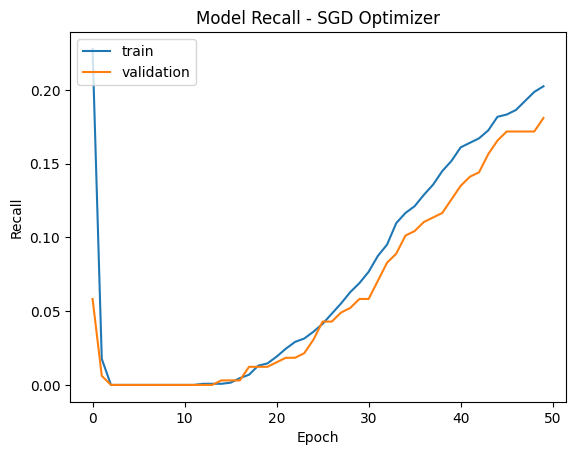

```python
#Plotting Train recall vs Validation recall
plt.plot(history_0.history['recall_1'])
plt.plot(history_0.history['val_recall_1'])
plt.title('Model Recall - SGD Optimizer')
plt.ylabel('Recall')
plt.xlabel('Epoch')
plt.legend(['train', 'validation'], loc='upper left')
plt.show()
```

```python
# Predicting the results using best as a threshold

y_train_pred = model_0.predict(X_train) # This line uses the trained model model_0 to make predictions on the training data (X_train).
# The predict function outputs a probability score for each sample, typically between 0 and 1,
# since the output layer has a sigmoid activation function (which outputs a probability for binary classification).

# Activation Thresholding for Output layer
y_train_pred = (y_train_pred > 0.5) # Since the model’s predictions are probabilities, this line converts the probabilities into binary classifications.
# If the probability is greater than 0.5, it is classified as True (1), otherwise, it is classified as False (0). Sigmoid

y_train_pred # After thresholding, y_train_pred will contain a series of True and False values that correspond to the model’s classification of each instance in the training set (X_train).
```

```
200/200 ━━━━━━━━━━━━━━━━━━━━ 0s 993us/step
```

```
array([[ True],
       [False],
       [False],
       ...,
       [False],
       [False],
       [False]])
```

```python
print("\nmodel_0.predict(X_train) gives you a probability score for each training sample.")
print(" • (y_train_pred > 0.5) converts these probabilities into binary predictions using a threshold of 0.5,")
print("    where values greater than 0.5 are classified as True (or 1) and those less than or equal to 0.5 as False (or 0).")
```

```
model_0.predict(X_train) gives you a probability score for each training sample.
 • (y_train_pred > 0.5) converts these probabilities into binary predictions using a threshold of 0.5,
    where values greater than 0.5 are classified as True (or 1) and those less than or equal to 0.5 as False (or 0).
```

```python
# Predicting on the validation set
y_val_pred = model_0.predict(X_val)
y_val_pred = (y_val_pred > 0.5)

# Now you can store the recall scores
train_metric_df.loc[model_name] = recall_score(y_train, y_train_pred)
valid_metric_df.loc[model_name] = recall_score(y_val, y_val_pred)
```

```
50/50 ━━━━━━━━━━━━━━━━━━━━ 0s 1ms/step
```

```python
model_name = "Neutral Network with SGD"

train_metric_df.loc[model_name] = recall_score(y_train, y_train_pred)
valid_metric_df.loc[model_name] = recall_score(y_val, y_val_pred)
```

**Classification report**

```python
# Classification report
print(f"\033[33mClassification report for the training set:\n")
cr = classification_report(y_train, y_train_pred)
print(cr)
```

```
Classification report for the training set:

              precision    recall  f1-score   support

           0       0.88      0.96      0.92      5096
           1       0.77      0.46      0.58      1304

    accuracy                           0.86      6400
   macro avg       0.82      0.71      0.75      6400
weighted avg       0.85      0.86      0.85      6400
```

```python
# Classification report
print(f"\033[32mClassification report for the validation set:\n")
cr = classification_report(y_val, y_val_pred)
print(cr)
```

[output not shown]

**Confusion matrix**

```
Training Confusion Matrix Predictions with the 6,400 (Training) dataset:
```

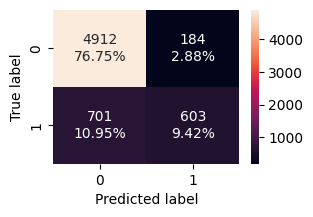

```python
print(f"\033[33mTraining Confusion Matrix Predictions with the 6,400 (Training) dataset:\033[0m\n")
make_confusion_matrix(y_train, y_train_pred)
```

```python
print(f"\033[32mValidation Confusion Matrix Predictions with the 1,600 (Validation) dataset:\033[0m\n")
make_confusion_matrix(y_val, y_val_pred)
```

[output not shown]

```
Validation Confusion Matrix Predictions with the 1,600 (Validation) dataset:
```

```python
result_df = train_metric_df - valid_metric_df # Calculates the Recall difference between the training and the validation.
print(result_df.head(1))  # Displays the first row
# Display just the last value in the first row as percentage
last_value_first_row = result_df.iloc[0, -1]  # Using iloc to access the first row and last column
print(f"\033[34m\nDelta between Training and Validation Recall values is: {last_value_first_row * 100:.2f}%\033[0m")  # Prints the value in the last cell of the first row
```

[output not shown]

```python
# Back Propagation Illustration - Utility Function

import time
import sys

# ANSI color codes
RED = "\033[31m"
GREEN = "\033[32m"
ORANGE = "\033[33m"
RESET = "\033[0m"

print("\nIllustration of -Back Propagation- to nodes with stronger influence after wights are updated with a keras Optimizer")

# Function to animate dashes moving from right to left, with "updated weight" in the middle
def animate_dashes_with_weight_in_middle(total_time=10, speed=0.1, asterisk_color="GREEN", dash_color="RED"):
    # Choose dash color based on user input
    if dash_color == "RED":
        dash_color = RED
    elif dash_color == "GREEN":
        dash_color = GREEN
    elif dash_color == "ORANGE":
        dash_color = ORANGE
    else:
        dash_color = RESET  # Default to no color if an invalid option is given

    # Choose asterisk color
    if asterisk_color == "RED":
        asterisk_color = RED
    elif asterisk_color == "GREEN":
        asterisk_color = GREEN
    elif asterisk_color == "ORANGE":
        asterisk_color = ORANGE
    else:
        asterisk_color = RESET  # Default to no color if an invalid option is given

    dash_width = 46  # Starting width of the dashes
    fixed_pos = 46  # Position where the asterisk [*] will stay fixed
    word = " updated weight "
    word_length = len(word)
    start_time = time.time()  # Record the starting time

    while time.time() - start_time < total_time:
        # Calculate the remaining space for the dashes
        remaining_space = fixed_pos - dash_width - 3  # 3 accounts for the length of [*]

        # Calculate the position to place the word in the middle
        total_length = dash_width + len(word) + 3  # Total length including dashes and word
        word_position = (total_length // 2) - (word_length // 2)  # Center the word

        # Create the dashes string
        dashes = '-' * dash_width

        # Insert the word into the dashes at the calculated position
        if word_position < dash_width:
            dashes = dashes[:word_position] + word + dashes[word_position + word_length:]

        # Print the line with dashes shrinking toward the asterisk [*]
        sys.stdout.write(f"\r{asterisk_color}[* neuron layer_i *] {dash_color}{dashes}{' ' * remaining_space}{RESET}")
        sys.stdout.flush()  # Force the output to appear immediately
        time.sleep(speed)   # Control the speed of the animation

        if dash_width == 0:
            dash_width = 45  # Reset dash width after dashes shrink to 0
        else:
            dash_width -= 1  # Decrease the number of dashes for the leftward effect

    # After timeout ends, clear the line and stop
    sys.stdout.write("\r" + " " * (fixed_pos + 3) + "\r")
    sys.stdout.flush()

# Run the animation (set timeout in seconds and specify colors)
animate_dashes_with_weight_in_middle(total_time=10, speed=0.08, asterisk_color="GREEN", dash_color="RED")

# Leave the illustration completed without animation
print(f"\r{GREEN}[* neuron layer_i *]{RED} <---------------------------------------- {ORANGE}[* neuron layer_i+1 *]")
```

```
Illustration of -Back Propagation- to nodes with stronger influence after wights are updated with a keras Optimizer
[* neuron layer_i *] <---------------------------------------- [* neuron layer_i+1 *]
```

```python
message = "Essentially:\nHow fast the global minimum is found (by Error Loss) is a function of the chosen Keras optimizers \n" \
          "during the backflow propagation with updated weights and strengths of signals between neurons."

# Run the animation (set timeout in seconds and specify color: "RED", "GREEN", or "ORANGE")
animate_dashes_with_fixed_asterisk(total_time=5, speed=0.08, color="GREEN")
print(f"\r{GREEN}[* neuron layer_i *]{GREEN} ----------------------------------------- {ORANGE}[* neuron layer_i+1 *]")

# Run the animation (set timeout in seconds and specify colors)
animate_dashes_with_weight_in_middle(total_time=5, speed=0.08, asterisk_color="GREEN", dash_color="RED")
print(f"\r{GREEN}[* neuron later_i *]{RED} <---------------------------------------- {ORANGE}[* neuron layer_i+1 *]{RESET}")

print(message)
```

```
[* neuron layer_i *] ----------------------------------------- [* neuron layer_i+1 *]
[* neuron later_i *] <---------------------------------------- [* neuron layer_i+1 *]
Essentially:
How fast the global minimum is found (by Error Loss) is a function of the chosen Keras optimizers
during the backflow propagation with updated weights and strengths of signals between neurons.
```

## Model Performance Improvement -------------------------------------- Section

**This is where the computational resources versus the prediction efficiency get tweaked for fun and profit ;-) ...**

Models Optimization Overview:

| # | Model | Optimizer | Regularization | Batch Normalization |
| --- | --- | --- | --- | --- |
| 1 | NN | Adam | n/a | n/a |
| 2 | NN | Adam | Dropout | n/a |
| 3 | NN | SGD | n/a | Balanced |
| 4 | NN | Adam | n/a | Balanced |
| 5 | NN | Adam | Dropout | Balanced |

- Balanced Data is a data preprocessing step that ensures fair representation of classes before training even begins.
- Balanced Data ensures that the model learns equally well across all classes, avoiding class bias, particularly in classification tasks.
- Batch Normalization helps the model train more efficiently and reduces issues like vanishing or exploding gradients.
- Batch Normalization operates at the model level during training, normalizing activations layer by layer.
- Dropout introduces noise by dropping random neurons, forcing the model to learn more robust features.
- Dropout and Batch Normalization both help prevent overfitting and improve generalization during training, while Balanced Data ensures the data used for training is representative and fair, preventing bias in the model.
- Dropout is a form of regularization because it adds randomness and noise to the training process, which prevents the model from relying too much on specific neurons and memorizing training data. Like other regularization techniques (e.g., L1/L2 regularization), Dropout helps the model generalize better to unseen data, reducing overfitting and improving performance on test data.

Other Regularization Techniques asides from Dropout:

- L2 Regularization (Ridge): Penalizes the model for having large weights, discouraging complex models.
- L1 Regularization (Lasso): Encourages sparsity in weights, leading to feature selection.

keras Optimizers:

- Backpropagation computes the gradientst to locate the local/global minimum.
- SGD, Adam, RMSprop and AdaGrad Optimizers from keras.optimizers use these gradients to update the weights across all layers.

### (1) Neural Network with Adam Optimizer - - Model Performance Improvement

**Adam Optimizer:** The **Adam (Adaptive Moment Estimation)** optimizer is a popular gradient-based optimization algorithm that combines the best properties of two other methods: AdaGrad (adaptive learning rates) and RMSProp (root mean square propagation). It adjusts the learning rate dynamically for each parameter and uses momentum to accelerate convergence.

**Advantages:**

- **Adaptive learning rate**: Adam automatically adjusts the learning rates for each parameter during training, making it efficient and effective across a wide range of problems.
- **Momentum**: It uses momentum to speed up convergence by considering past gradients, which helps avoid oscillations.
- **Efficient**: Works well for large datasets and with high-dimensional data.
- **Less tuning required**: Works well with little parameter tuning (learning rate, batch size, etc.), reducing the need for extensive experimentation.

**Disadvantages:**

- **Memory intensive**: Adam stores additional parameters (momentum and squared gradient averages), which can increase memory usage.
- **Overfitting**: Sometimes, it can lead to overfitting as it adapts too aggressively, especially on complex models.
- **May not generalize well**: While Adam is good for fast convergence, it may not always provide the best final solution compared to simpler optimizers like SGD.

```python
backend.clear_session()
#Fixing the seed for random number generators so that we can ensure we receive the same output everytime
np.random.seed(2)
random.seed(2)
tf.random.set_seed(2)
```

```python
# Initializing the neural network
model_1 = Sequential()

# Adding the input layer with 64 neurons and ReLU as the activation function
model_1.add(Dense(64, activation='relu', input_dim=X_train.shape[1]))

# Adding a hidden layer with 32 neurons and ReLU as the activation function
model_1.add(Dense(32, activation='relu'))

# Adding the output layer with 1 neuron and sigmoid as the activation function
model_1.add(Dense(1, activation='sigmoid'))
```

```python
#Complete the code to use Adam as the optimizer.
optimizer = tf.keras.optimizers.Adam() # Adam is a popular optimization algorithm that combines the advantages of both AdaGrad (adaptive learning rate) and RMSProp (root mean square propagation), making it a good choice for most deep learning models.

# uncomment one of the following lines to define the metric to be used
# metric = 'accuracy'
metric = keras.metrics.Recall() # Measures how many true positives were identified correctly (useful for imbalanced datasets).
# metric = keras.metrics.Precision()
# metric = keras.metrics.F1Score()
```

```python
# Complete the code to compile the model with binary cross entropy as the loss function and recall as the metric
model_1.compile(loss='binary_crossentropy', optimizer=optimizer, metrics=[keras.metrics.Recall()])
```